# Data Analysis, Preprocessing, Data Reduction

# Data Understanding and Exploratory Data Analysis

# Task 1: Data Analysis & Preprocessing (25 Marks)

```python
from google.colab import drive
drive.mount('/content/drive')
```

```python
# modify this cell in case more libraries are needed
import pandas as pd
import numpy as np
import seaborn as sns
```

```python
# import data
df = pd.read_csv('/content/drive/MyDrive/property.csv')
df.head(5)
```

|  | property_id | location_id | page_url | property_type | price | location | city | province_name | latitude | longitude | baths | area | purpose | bedrooms | date_added | agency | agent | Area Type | Area Size | Area Category |
| --- | --- | --- | --- | --- | --- | --- | --- | --- | --- | --- | --- | --- | --- | --- | --- | --- | --- | --- | --- | --- |
| 0 | 237062 | 3325 | https://www.zameen.com/Property/g_10_g_10_2_gr... | Flat | 10000000 | G-10 | Islamabad | Islamabad Capital | 33.679890 | 73.012640 | 2 | 4 Marla | For Sale | 2 | 02-04-2019 | NaN | NaN | Marla | 4.0 | 0-5 Marla |
| 1 | 346905 | 3236 | https://www.zameen.com/Property/e_11_2_service... | Flat | 6900000 | E-11 | Islamabad | Islamabad Capital | 33.700993 | 72.971492 | 3 | 5.6 Marla | For Sale | 3 | 05-04-2019 | NaN | NaN | Marla | 5.6 | 5-10 Marla |
| 2 | 386513 | 764 | https://www.zameen.com/Property/islamabad_g_15... | House | 16500000 | G-15 | Islamabad | Islamabad Capital | 33.631486 | 72.926559 | 6 | 8 Marla | For Sale | 5 | 07-17-2019 | NaN | NaN | Marla | 8.0 | 5-10 Marla |
| 3 | 656161 | 340 | https://www.zameen.com/Property/islamabad_bani... | House | 43500000 | Bani Gala | Islamabad | Islamabad Capital | 33.707573 | 73.151199 | 4 | 2 Kanal | For Sale | 4 | 04-05-2019 | NaN | NaN | Kanal | 2.0 | 1-5 Kanal |
| 4 | 841645 | 3226 | https://www.zameen.com/Property/dha_valley_dha... | House | 7000000 | DHA Defence | Islamabad | Islamabad Capital | 33.492591 | 73.301339 | 3 | 8 Marla | For Sale | 3 | 07-10-2019 | Easy Property | Muhammad Junaid Ceo Muhammad Shahid Director | Marla | 8.0 | 5-10 Marla |

### (a) Data Analysis (5 Marks)

**Enlist numerical and categorical attributes.**

> Numerical Attributes :property_id, location_id, price,latitude longitude baths, bedrooms, Area Size

> Categorical Attributes: property_type, purpose, Area Type, Area Category

### (b) Summary Statistics (5 Marks)

```python
# print the summary statistics of the numerical attributes of the data (mean, std, min, 25%, 50%, 75%, max, counts).

print("Mean:")
print(df[["Area Size","price", "baths", "bedrooms"]].mean())

print("\nSTD:")
print(df[["Area Size","price", "baths", "bedrooms"]].std())

print("\nMIN:")
print(df[["Area Size","price", "baths", "bedrooms"]].min())

print("\nMAX:")
print(df[["Area Size","price", "baths", "bedrooms"]].max())

print("\n25%:")
print(df[["Area Size","price", "baths", "bedrooms"]].quantile(0.25))

print("\n50%:")
print(df[["Area Size","price", "baths", "bedrooms"]].quantile(0.50))

print("\n75%:")
print(df[["Area Size","price", "baths", "bedrooms"]].quantile(0.75))

print("\nCOUNTS:")
print(df[["Area Size","price", "baths", "bedrooms"]].count())


#statistics.stdev()
```

```
Mean:
Area Size    5.892188e+00
price        1.776576e+07
baths        2.874227e+00
bedrooms     3.179422e+00
dtype: float64

STD:
Area Size    5.778327e+00
price        3.531003e+07
baths        2.463400e+00
bedrooms     1.971401e+00
dtype: float64

MIN:
Area Size    0.0
price        0.0
baths        0.0
bedrooms     0.0
dtype: float64

MAX:
Area Size    8.000000e+02
price        2.000000e+09
baths        4.030000e+02
bedrooms     6.800000e+01
dtype: float64

25%:
Area Size         3.0
price        175000.0
baths             0.0
bedrooms          2.0
Name: 0.25, dtype: float64

50%:
Area Size          5.0
price        8500000.0
baths              3.0
bedrooms           3.0
Name: 0.5, dtype: float64

75%:
Area Size           8.0
price        19500000.0
baths               4.0
bedrooms            4.0
Name: 0.75, dtype: float64

COUNTS:
Area Size    168446
price        168446
baths        168446
bedrooms     168446
dtype: int64
```

### (c) Dataframe Size (5 Marks)

```python
# show the number of records (rows) and number of attributes (columns) of the dataframe
print(len(df),"x",len(df.columns))
```

```
168446 x 20
```

### (d) Unique Values (5 Marks)

```python
# print the count of unique entries in (1) Property (2) City and (3) Province
print("Count of unique entries in property type: ", len(df["property_type"].unique()))
print("Count of unique entries in city: ", len(df["city"].unique()))
print("Count of unique entries in Province: ", len(df["province_name"].unique()))
```

```
Count of unique entries in property type:  7
Count of unique entries in city:  5
Count of unique entries in Province:  3
```

### (e) Missing Entries (5 Marks)

```python
# print the number of missing values in each column
print("Number of missing values in each column \n")
for col in df.columns:
 print(col, " : ", df[col].isna().sum())
```

```
Number of missing values in each column

property_id  :  0
location_id  :  0
page_url  :  0
property_type  :  0
price  :  0
location  :  0
city  :  0
province_name  :  0
latitude  :  0
longitude  :  0
baths  :  0
area  :  0
purpose  :  0
bedrooms  :  0
date_added  :  0
agency  :  44071
agent  :  44072
Area Type  :  0
Area Size  :  0
Area Category  :  0
```

# Task 2: Exploratory Data Analysis & Visualization (30 Marks)

### 1.Boxplots (5 Marks)

One of the columns area that you will plot a boxplot for is "area".  
Notice the values are of the format: "x Marla" or "y Kanal".

Normalize the column according the following units:

1 Kanal = 20 Marla  
1 Marla = 272.251 Square Foot

For example: 1.6 Kanal = **8712.032**

```python
for x in range(len(df)):
 if df.at[x, 'Area Type'] == "Marla":
   df.at[x, 'area'] = (str( round((1/20)*float(df.at[x, 'Area Size']),1) ) + " Kanal")
   df.at[x, 'Area Size'] = ( round((1/20)*float(df.at[x, 'Area Size']),1) )
   df.at[x, 'Area Type'] = "Kanal"
```

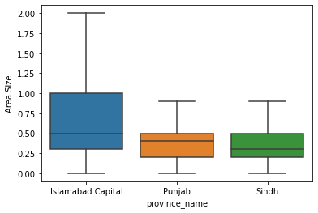

```python
# derive boxplots for "area" after grouping dataset by (1) Province (2) City
sns.boxplot(x="province_name", y="Area Size", data=df, showfliers=False);
```

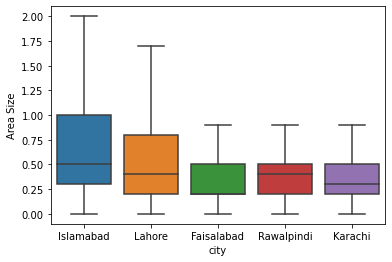

```python
sns.boxplot(x="city", y="Area Size", data=df, showfliers=False);
```

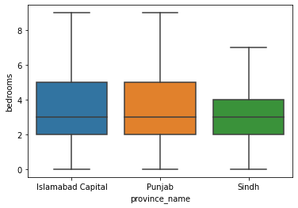

```python
# derive boxplots for "bedrooms" after grouping dataset by (1) Province (2) City
sns.boxplot(x="province_name", y="bedrooms", data=df, showfliers=False);
```

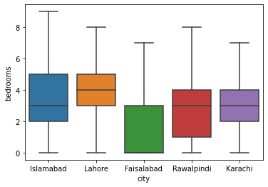

```python
sns.boxplot(x="city", y="bedrooms", data=df, showfliers=False);
```

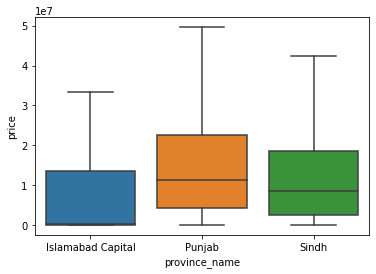

```python
# derive boxplots for "price" after grouping dataset by (1) Province (2) City
sns.boxplot(x="province_name", y="price", data=df, showfliers=False);
```

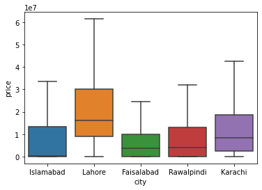

```python
sns.boxplot(x="city", y="price", data=df, showfliers=False);
```

### 2. Barplot (5 Marks)

#### (a) Area

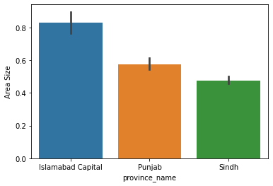

```python
# create a barplot plotting the average area of properties in each province
sns.barplot(data=df, x="province_name", y="Area Size")
```

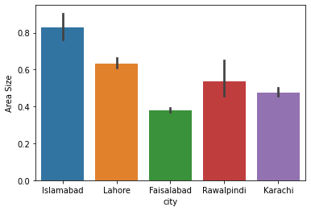

```python
# create a barplot plotting the average area of properties in each city
sns.barplot(data=df, x="city", y="Area Size")
```

#### (b) Price

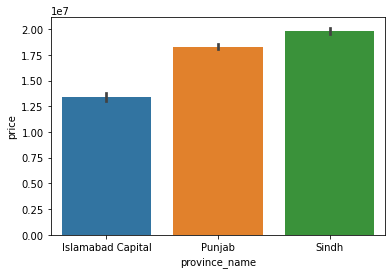

```python
# create a barplot plotting the average price of properties in each province
sns.barplot(data=df, x="province_name", y="price")
```

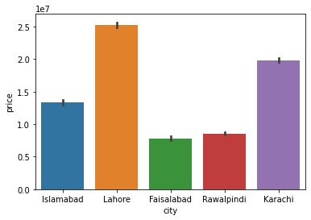

```python
# create a barplot plotting the average price of properties in each city
sns.barplot(data=df, x="city", y="price")
```

#### (c) Bedrooms

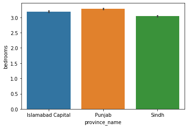

```python
# create a barplot plotting the average number of bedrooms of properties in each province
sns.barplot(data=df, x="province_name", y="bedrooms")
```

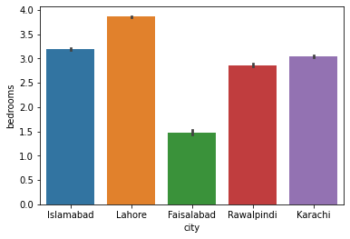

```python
# create a barplot plotting the average number of bedrooms of properties in each city
sns.barplot(data=df, x="city", y="bedrooms")
```

### 3. Correlation Between Attributes (10 Marks)

#### (a) Correlation

```python
# create a backup for df and drop the columns that are irrelevant in your opinion
backupdf = df.copy()

df.drop(columns=['location', 'area','Area Category', 'Area Type','page_url', 'date_added', 'agent', 'agency'], inplace=True)

df.head(3)
```

|  | property_id | location_id | property_type | price | city | province_name | latitude | longitude | baths | purpose | bedrooms | Area Size |
| --- | --- | --- | --- | --- | --- | --- | --- | --- | --- | --- | --- | --- |
| 0 | 237062 | 3325 | Flat | 10000000 | Islamabad | Islamabad Capital | 33.679890 | 73.012640 | 2 | For Sale | 2 | 0.2 |
| 1 | 346905 | 3236 | Flat | 6900000 | Islamabad | Islamabad Capital | 33.700993 | 72.971492 | 3 | For Sale | 3 | 0.3 |
| 2 | 386513 | 764 | House | 16500000 | Islamabad | Islamabad Capital | 33.631486 | 72.926559 | 6 | For Sale | 5 | 0.4 |

```python
# convert all categorical attributes to numerical attributes (you may use dictionary to map the values to integers).

df['purpose'].replace(['For Sale', 'For Rent'],
                        [0, 1], inplace=True)
df['property_type'].replace(['Flat', 'House', 'Penthouse', 'Farm House', 'Lower Portion', 'Upper Portion', 'Room'],
                        [0, 1, 2, 3, 4, 5, 6], inplace=True)
df['city'].replace(['Islamabad', 'Lahore', 'Faisalabad', 'Rawalpindi', 'Karachi'],
                        [0, 1, 2, 3, 4], inplace=True)
df['province_name'].replace(['Islamabad Capital', 'Punjab', 'Sindh'],
                        [0, 1, 2], inplace=True)
```

```python
# compute correlation
df.corr()
```

|  | property_id | location_id | property_type | price | city | province_name | latitude | longitude | baths | purpose | bedrooms | Area Size |
| --- | --- | --- | --- | --- | --- | --- | --- | --- | --- | --- | --- | --- |
| property_id | 1.000000 | 0.006564 | 0.027806 | -0.029669 | -0.000131 | 0.006900 | -0.010461 | -0.002722 | -0.101769 | 0.036089 | -0.066577 | 0.001701 |
| location_id | 0.006564 | 1.000000 | -0.114367 | -0.098426 | 0.334706 | 0.323104 | -0.293129 | -0.282903 | -0.121941 | -0.136802 | -0.138452 | -0.024079 |
| property_type | 0.027806 | -0.114367 | 1.000000 | -0.112190 | -0.124822 | -0.190470 | 0.172088 | 0.099994 | -0.092100 | 0.445256 | -0.112729 | 0.029680 |
| price | -0.029669 | -0.098426 | -0.112190 | 1.000000 | 0.007537 | 0.064750 | -0.071193 | -0.019225 | 0.230205 | -0.314965 | 0.314145 | 0.107191 |
| city | -0.000131 | 0.334706 | -0.124822 | 0.007537 | 1.000000 | 0.931164 | -0.830598 | -0.839331 | -0.113837 | -0.107245 | -0.095631 | -0.028054 |
| province_name | 0.006900 | 0.323104 | -0.190470 | 0.064750 | 0.931164 | 1.000000 | -0.916667 | -0.802242 | -0.057024 | -0.246643 | -0.034173 | -0.028160 |
| latitude | -0.010461 | -0.293129 | 0.172088 | -0.071193 | -0.830598 | -0.916667 | 1.000000 | 0.926888 | 0.053107 | 0.177302 | 0.030961 | 0.022248 |
| longitude | -0.002722 | -0.282903 | 0.099994 | -0.019225 | -0.839331 | -0.802242 | 0.926888 | 1.000000 | 0.099506 | 0.019892 | 0.079962 | 0.019277 |
| baths | -0.101769 | -0.121941 | -0.092100 | 0.230205 | -0.113837 | -0.057024 | 0.053107 | 0.099506 | 1.000000 | -0.136562 | 0.669210 | 0.022908 |
| purpose | 0.036089 | -0.136802 | 0.445256 | -0.314965 | -0.107245 | -0.246643 | 0.177302 | 0.019892 | -0.136562 | 1.000000 | -0.178897 | 0.015732 |
| bedrooms | -0.066577 | -0.138452 | -0.112729 | 0.314145 | -0.095631 | -0.034173 | 0.030961 | 0.079962 | 0.669210 | -0.178897 | 1.000000 | 0.028001 |
| Area Size | 0.001701 | -0.024079 | 0.029680 | 0.107191 | -0.028054 | -0.028160 | 0.022248 | 0.019277 | 0.022908 | 0.015732 | 0.028001 | 1.000000 |

```python
# visualize using heatmap
sns.heatmap(df, annot=True)
```

[output not shown]

#### (b) Chi Square Test

```python
df2 = pd.read_csv('/content/drive/MyDrive/titanic.csv')
df2.head()
```

|  | PassengerId | Survived | Pclass | Name | Sex | Age | SibSp | Parch | Ticket | Fare | Cabin | Embarked |
| --- | --- | --- | --- | --- | --- | --- | --- | --- | --- | --- | --- | --- |
| 0 | 1 | 0 | 3 | Braund, Mr. Owen Harris | male | 22.0 | 1 | 0 | A/5 21171 | 7.2500 | NaN | S |
| 1 | 2 | 1 | 1 | Cumings, Mrs. John Bradley (Florence Briggs Th... | female | 38.0 | 1 | 0 | PC 17599 | 71.2833 | C85 | C |
| 2 | 3 | 1 | 3 | Heikkinen, Miss. Laina | female | 26.0 | 0 | 0 | STON/O2. 3101282 | 7.9250 | NaN | S |
| 3 | 4 | 1 | 1 | Futrelle, Mrs. Jacques Heath (Lily May Peel) | female | 35.0 | 1 | 0 | 113803 | 53.1000 | C123 | S |
| 4 | 5 | 0 | 3 | Allen, Mr. William Henry | male | 35.0 | 0 | 0 | 373450 | 8.0500 | NaN | S |

```python
# compute chi square test for categorical attributes of the imported dataset
```

[output not shown]

### 4. Geospatial Analysis (10 Marks)

Use Pakistan's map to plot the location of the properties given in the dataset using the longitude and latitude attributes. Note that this part is very open ended. You can refer to the documentations of the following libraries to achieve this task:

- Matplotlib
- Folium
- GeoPandas
- Plotly

```python
# (optional) you may use the following variables to acquire the coordinates of the corners of the map.
# note that you may need to clear some outliers first

max_lat = df['latitude'].max()
max_lon = df['longitude'].max()

min_lat = df['latitude'].min()
min_lon = df['longitude'].min()

print(max_lat, max_lon, min_lat, min_lon)
```

```
73.184088 80.16143000000001 11.052446 25.906027
```

```python
pip install folium
```

```python
import folium
map=folium.Map(location=[29.767638, 69.458617],zoom_start=6)
#for x in range(len(df)): #FOR ALL OF THE POINTS IN THE DATASET
for x in range(30):
  map.add_child(folium.Marker(location=[df.at[x, 'latitude'],df.at[x, 'longitude']],icon=folium.Icon(color='green')))
map
```

Make this Notebook Trusted to load map: File -> Trust Notebook

[interactive chart not shown]

# Task 3: Dimensionality Reduction (45 Marks)

Dimensionality reduction is a technique in data mining that aims to reduce the number of features (or dimensions) in a dataset while retaining as much information as possible. The goal of dimensionality reduction is to simplify data, remove noise, reduce computational cost, and make it easier to visualize high-dimensional data. Common techniques for dimensionality reduction include principal component analysis (PCA), linear discriminant analysis (LDA), t-distributed stochastic neighbor embedding (t-SNE), and singular value decomposition (SVD). These techniques can be used individually or in combination to transform the original high-dimensional data into a lower-dimensional representation.

```python
# !pip install factor_analyzer --quiet
```

```python
# importing the required libraries

from sklearn.manifold import TSNE
from sklearn.decomposition import PCA
from sklearn.decomposition import NMF
from sklearn.preprocessing import MaxAbsScaler
from sklearn.decomposition import FactorAnalysis
import pandas as pd
from sklearn.preprocessing import StandardScaler
import matplotlib.pyplot as plt
import pandas as pd
import numpy as np
import seaborn as sns
```

Dataset Link: https://archive.ics.uci.edu/ml/machine-learning-databases/wine-quality/

download *winequalitey-red.csv* and *winequality-white.csv* datasets

**a)** Loading and preprocessing (2 Marks)

- Load the red wine dataset
- Create a column with label "red_wine"
- Load the white wine dataset
- Create a column with label "white_wine"
- Combine the both datasets row-wise

```python
# load data and preprocess
df3 = pd.read_csv('/content/drive/MyDrive/winequality-red.csv')
df3["wine_type"] = "red"
df4 = pd.read_csv('/content/drive/MyDrive/winequality-white.csv')
df4["wine_type"] = "white"

df_combined = pd.concat([df3, df4], ignore_index=True)
df_combined
```

|  | fixed acidity | volatile acidity | citric acid | residual sugar | chlorides | free sulfur dioxide | total sulfur dioxide | density | pH | sulphates | alcohol | quality | wine_type |
| --- | --- | --- | --- | --- | --- | --- | --- | --- | --- | --- | --- | --- | --- |
| 0 | 7.4 | 0.70 | 0.00 | 1.9 | 0.076 | 11.0 | 34.0 | 0.99780 | 3.51 | 0.56 | 9.4 | 5 | red |
| 1 | 7.8 | 0.88 | 0.00 | 2.6 | 0.098 | 25.0 | 67.0 | 0.99680 | 3.20 | 0.68 | 9.8 | 5 | red |
| 2 | 7.8 | 0.76 | 0.04 | 2.3 | 0.092 | 15.0 | 54.0 | 0.99700 | 3.26 | 0.65 | 9.8 | 5 | red |
| 3 | 11.2 | 0.28 | 0.56 | 1.9 | 0.075 | 17.0 | 60.0 | 0.99800 | 3.16 | 0.58 | 9.8 | 6 | red |
| 4 | 7.4 | 0.70 | 0.00 | 1.9 | 0.076 | 11.0 | 34.0 | 0.99780 | 3.51 | 0.56 | 9.4 | 5 | red |
| ... | ... | ... | ... | ... | ... | ... | ... | ... | ... | ... | ... | ... | ... |
| 6492 | 6.2 | 0.21 | 0.29 | 1.6 | 0.039 | 24.0 | 92.0 | 0.99114 | 3.27 | 0.50 | 11.2 | 6 | white |
| 6493 | 6.6 | 0.32 | 0.36 | 8.0 | 0.047 | 57.0 | 168.0 | 0.99490 | 3.15 | 0.46 | 9.6 | 5 | white |
| 6494 | 6.5 | 0.24 | 0.19 | 1.2 | 0.041 | 30.0 | 111.0 | 0.99254 | 2.99 | 0.46 | 9.4 | 6 | white |
| 6495 | 5.5 | 0.29 | 0.30 | 1.1 | 0.022 | 20.0 | 110.0 | 0.98869 | 3.34 | 0.38 | 12.8 | 7 | white |
| 6496 | 6.0 | 0.21 | 0.38 | 0.8 | 0.020 | 22.0 | 98.0 | 0.98941 | 3.26 | 0.32 | 11.8 | 6 | white |

6497 rows × 13 columns

**b)** Now standardize the dataset. Plot the scatter plot using any two attributes. Use different colors for red wine and white wine labels. **(8 Marks)**

```python
# standerdize the dataset
df_scaled = df_combined.copy()

#df_combined.iloc[:,0:-1] = df_combined.iloc[:,0:-1].apply(lambda x: (x-x.mean())/ x.std(), axis=0)
df_scaled.iloc[:,0:-1] = StandardScaler().fit_transform(df_combined.iloc[:,0:-1])

df_scaled
```

|  | fixed acidity | volatile acidity | citric acid | residual sugar | chlorides | free sulfur dioxide | total sulfur dioxide | density | pH | sulphates | alcohol | quality | wine_type |
| --- | --- | --- | --- | --- | --- | --- | --- | --- | --- | --- | --- | --- | --- |
| 0 | 0.142473 | 2.188833 | -2.192833 | -0.744778 | 0.569958 | -1.100140 | -1.446359 | 1.034993 | 1.813090 | 0.193097 | -0.915464 | -0.937230 | red |
| 1 | 0.451036 | 3.282235 | -2.192833 | -0.597640 | 1.197975 | -0.311320 | -0.862469 | 0.701486 | -0.115073 | 0.999579 | -0.580068 | -0.937230 | red |
| 2 | 0.451036 | 2.553300 | -1.917553 | -0.660699 | 1.026697 | -0.874763 | -1.092486 | 0.768188 | 0.258120 | 0.797958 | -0.580068 | -0.937230 | red |
| 3 | 3.073817 | -0.362438 | 1.661085 | -0.744778 | 0.541412 | -0.762074 | -0.986324 | 1.101694 | -0.363868 | 0.327510 | -0.580068 | 0.207999 | red |
| 4 | 0.142473 | 2.188833 | -2.192833 | -0.744778 | 0.569958 | -1.100140 | -1.446359 | 1.034993 | 1.813090 | 0.193097 | -0.915464 | -0.937230 | red |
| ... | ... | ... | ... | ... | ... | ... | ... | ... | ... | ... | ... | ... | ... |
| 6492 | -0.783214 | -0.787650 | -0.197054 | -0.807837 | -0.486252 | -0.367664 | -0.420128 | -1.186161 | 0.320319 | -0.210144 | 0.593818 | 0.207999 | white |
| 6493 | -0.474652 | -0.119460 | 0.284686 | 0.537425 | -0.257883 | 1.491697 | 0.924588 | 0.067824 | -0.426067 | -0.478971 | -0.747766 | -0.937230 | white |
| 6494 | -0.551792 | -0.605417 | -0.885253 | -0.891916 | -0.429160 | -0.029599 | -0.083949 | -0.719251 | -1.421248 | -0.478971 | -0.915464 | 0.207999 | white |
| 6495 | -1.323198 | -0.301694 | -0.128234 | -0.912936 | -0.971538 | -0.593041 | -0.101642 | -2.003251 | 0.755710 | -1.016626 | 1.935402 | 1.353228 | white |
| 6496 | -0.937495 | -0.787650 | 0.422326 | -0.975995 | -1.028631 | -0.480353 | -0.313966 | -1.763127 | 0.258120 | -1.419867 | 1.096912 | 0.207999 | white |

6497 rows × 13 columns

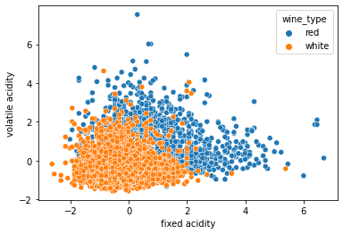

```python
# scatter plot

sns.scatterplot(data=df_scaled, x="fixed acidity", y="volatile acidity", hue="wine_type")
```

t-SNE (t-distributed stochastic neighbor embedding) is a popular dimensionality reduction technique used in data mining and machine learning. It is a non-linear method that projects high-dimensional data into a low-dimensional space while preserving the global structure of the data. t-SNE works by minimizing the divergence between the probability distributions of the similarities between data points in the high-dimensional space and the low-dimensional space.

**c)** Perform t-SNE on the dataset. Now plot the scatter plot for these two attributes. Use different colors for red wine and white wine labels. **(8 Marks)**

```python
# Tsne

df_embedded = TSNE(n_components=2, learning_rate='auto',  init='random', perplexity=3).fit_transform(df_combined.iloc[:,0:-1])

#df_embedded = np.array(df_scaled.iloc[:,0:-1])
#df_embedded = TSNE(n_components=2, learning_rate='auto', init='random').fit_transform(df_embedded)
df_embedded

dfe = pd.DataFrame(df_embedded)

dfe['wine_type'] = df_combined.iloc[:,-1:]

dfe
```

|  | 0 | 1 | wine_type |
| --- | --- | --- | --- |
| 0 | 37.002354 | 96.824402 | red |
| 1 | 22.642340 | -89.298141 | red |
| 2 | -50.431595 | -12.715092 | red |
| 3 | -38.158386 | -20.629154 | red |
| 4 | 37.000477 | 96.823608 | red |
| ... | ... | ... | ... |
| 6492 | -19.040018 | -9.271578 | white |
| 6493 | -22.226921 | -60.642101 | white |
| 6494 | -12.411817 | 26.823160 | white |
| 6495 | -45.489666 | 50.889698 | white |
| 6496 | -56.118259 | 13.563695 | white |

6497 rows × 3 columns

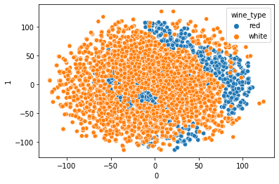

```python
#  Scatterplot
sns.scatterplot(data=dfe, x=dfe[0], y=dfe[1], hue="wine_type")
```

PCA (Principal Component Analysis) is a widely used linear dimensionality reduction technique in data mining and machine learning. The goal of PCA is to reduce the number of features in a dataset while retaining as much information as possible.

**d)** Perform PCA on the dataset. Project the input attributes onto the first two principal components and plot the scatter plot for these two attributes. Use different colors for red wine and white wine labels. **(8 Marks)**

```python
# PCA

pca = PCA(n_components=3)

pca_features = pca.fit_transform(df_scaled.iloc[:,0:-1])

print('Shape before PCA: ', df_scaled.shape)
print('Shape after PCA: ', pca_features.shape)

pca_df = pd.DataFrame(
    data=pca_features)

pca_df['wine_type'] = df_scaled.iloc[:,-1:]

pca_df
```

```
Shape before PCA:  (6497, 13)
Shape after PCA:  (6497, 3)
```

|  | 0 | 1 | 2 | wine_type |
| --- | --- | --- | --- | --- |
| 0 | -3.348438 | 0.568926 | -2.727386 | red |
| 1 | -3.228595 | 1.197335 | -1.998904 | red |
| 2 | -3.237468 | 0.952580 | -1.746578 | red |
| 3 | -1.672561 | 1.600583 | 2.856552 | red |
| 4 | -3.348438 | 0.568926 | -2.727386 | red |
| ... | ... | ... | ... | ... |
| 6492 | 0.112718 | -1.912247 | -0.061138 | white |
| 6493 | 1.720296 | 1.009571 | -0.662488 | white |
| 6494 | 0.626922 | -0.622145 | -0.149483 | white |
| 6495 | 0.491934 | -3.755928 | -0.080284 | white |
| 6496 | 0.761555 | -2.767840 | 0.176820 | white |

6497 rows × 4 columns

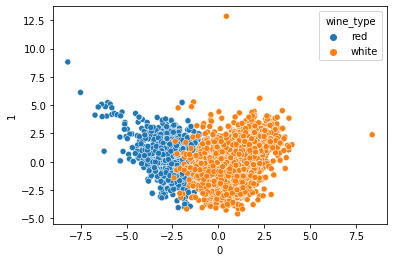

```python
# Scatterplot
sns.scatterplot(data=pca_df, x=pca_df[0], y=pca_df[1], hue="wine_type")
```

Non-Negative Matrix Factorization (NNMF) is a dimensionality reduction technique in data mining and machine learning that factorizes a non-negative matrix into two non-negative matrices

**e)** Perform non-negative matrix factorization of the data matrix to 2-D and plot the scatter plot again for these (new) attributes. **(8 Marks)**

```python
# NMF
```

[output not shown]

```python
# Scatterplot
sns.scatterplot(data=df_combined, x="fixed acidity", y="volatile acidity", hue="wine_type")
```

[output not shown]

Factor Analysis is a statistical technique used for dimensionality reduction and pattern recognition in data mining and machine learning. It aims to explain the correlations between variables in a dataset by identifying a smaller number of underlying factors or latent variables.

**f)** Perfrom factor analysis to find two factors for the dataset. Plot the scatter plot again for these (new) attributes. **(8 Marks)**

```python
#  Factor Analysis
```

[output not shown]

```python
# Scatterplot
sns.scatterplot(data=df_combined, x="fixed acidity", y="volatile acidity", hue="wine_type")
```

[output not shown]